# Reproducing the marine seismic hazard-chain results

Quantitative Modelling of Marine Seismic Hazard Chains (NHESS) — one document that regenerates every table and figure

Shi, Hu, Zhang

2026-07-05

# 1 Overview

This single document reproduces **every number and figure** reported in the paper from the raw cascade tables in `data/`. Knit it (RStudio → *Knit*, or `rmarkdown::render("reproduce.Rmd")`) to regenerate:

| Output | Section |
| --- | --- |
| Marine network (39 nodes / 152 edges) | @ref(marine-network) |
| **Table 2** — node in/out degree | @ref(table-2-node-degrees) |
| **Table 3** — four-layer net flow | @ref(table-3-four-layer-net-flow) |
| **Table 4** — 15-class marine vs mainland | @ref(table-4-15-class-comparison) |
| **Figure 1** — marine network, in/out degree | @ref(figure-1) |
| **Figure 2** — marine vs mainland, 15 classes | @ref(figure-2) |
| **Figure 3 / Sect. 3.4** — robustness & sampling sufficiency | @ref(figure-3-robustness) |

**Paths are relative** (this file sits at the repository root) and use `file.path()`, which is correct on Windows, Linux and macOS alike — no per-OS branching is needed (R also accepts `/` on Windows). The operating system this run used is printed in the Session information at the end.

```r
## Required packages (install once): docxtractr, igraph, dplyr
for (p in c("docxtractr", "igraph", "dplyr"))
  if (!requireNamespace(p, quietly = TRUE))
    stop(sprintf("Please install.packages('%s')", p))
suppressMessages({library(igraph); library(dplyr)})
cat("Running on:", Sys.info()[["sysname"]], "| R", as.character(getRversion()), "\n")
```

```
## Running on: Linux | R 4.4.3
```

```r
## Relative paths from the repository root (cross-platform via file.path()).
data_dir   <- "data"
marine_f   <- file.path(data_dir, "marine", "tsunami_Dohmen_2025_EQ.docx")
mainland_f <- file.path(data_dir, "mainland_china",
                        paste0("earthquake_table_China_4_", c("E", "N", "SW", "NW"), ".docx"))
stopifnot(file.exists(marine_f), all(file.exists(mainland_f)))
```

# 2 Helper functions

`read_doc()` reads the first table of a `.docx`; the only column used is the machine-readable **`Proposed Encoding`** field (chains such as `SEQ,TS;TS,CFL;CFL,PP;`). `build_graph()` turns those encodings into a directed graph: chains are split on `;`, pairs on `,`, whitespace is trimmed so `" TS"` and `"TS"` are not treated as different nodes, and the union of all chains is de-duplicated. **Self-loops are retained** here (one edge, `PP -> PP`, exists in the record and is part of the 152-edge fine network; it is removed only for the 15-class comparison, exactly as the paper states).

```r
read_doc <- function(path) {
  tb <- docxtractr::docx_extract_tbl(docxtractr::read_docx(path), tbl_number = 1)
  as.data.frame(tb, check.names = FALSE)
}

## robustly locate the "Proposed Encoding" column (dot or space in the name)
encoding_of <- function(df) df[[ grep("Encoding", names(df), ignore.case = TRUE)[1] ]]

build_graph <- function(paths) {
  x   <- do.call(rbind, lapply(paths, read_doc))
  enc <- encoding_of(x)
  from <- character(0); to <- character(0)
  for (s in enc) for (seg in strsplit(s, ";")[[1]]) {
    pr <- trimws(strsplit(seg, ",")[[1]])
    if (length(pr) >= 2 && all(nzchar(pr[1:2]))) { from <- c(from, pr[1]); to <- c(to, pr[2]) }
  }
  final <- dplyr::distinct(data.frame(from = from, to = to))  # unique directed edges (self-loops kept)
  igraph::graph_from_data_frame(final, directed = TRUE)
}
```

# 3 Marine network

The fine marine network is built from tsunami_Dohmen_2025_EQ.docx (366 documented cascade chains, 39 peril codes).

```r
g_marine <- build_graph(marine_f)
cat(sprintf("Marine fine network: %d nodes, %d directed edges (incl. 1 self-loop PP->PP)\n",
            vcount(g_marine), ecount(g_marine)))
```

```
## Marine fine network: 39 nodes, 152 directed edges (incl. 1 self-loop PP->PP)
```

# 4 Table 2: node degrees

In/out degree of every node on the **fine** network (self-loop retained, so the PP self-loop contributes +1 to both PP’s in- and out-degree, giving PP = in 9 / out 1, as in the paper). `net = out − in`.

```r
deg_tab <- data.frame(
  Code = V(g_marine)$name,
  In   = degree(g_marine, mode = "in"),
  Out  = degree(g_marine, mode = "out"),
  Net  = degree(g_marine, mode = "out") - degree(g_marine, mode = "in"),
  row.names = NULL)
## the paper's Table 2 lists nodes with in- or out-degree >= 7 (upper quartile)
core <- deg_tab[deg_tab$In >= 7 | deg_tab$Out >= 7, ]
knitr::kable(core[order(-core$Out, -core$In), ], row.names = FALSE,
             caption = "Table 2 — core nodes (in- or out-degree >= 7).")
```

Table 2 — core nodes (in- or out-degree >= 7).

| Code | In | Out | Net |
| --- | --- | --- | --- |
| SEQ | 0 | 29 | 29 |
| CF | 14 | 13 | -1 |
| EQ | 0 | 13 | 13 |
| TS | 9 | 12 | 3 |
| CFL | 5 | 8 | 3 |
| FI | 7 | 7 | 0 |
| NF | 12 | 5 | -7 |
| PHF | 9 | 3 | -6 |
| BI | 11 | 1 | -10 |
| PP | 9 | 1 | -8 |

# 5 Table 3: four-layer net flow

Nodes are aggregated into the four cascade layers; **net flow = out − in** summed over each layer’s members. Expected: **+42 / +1 / −16 / −27** (sums to 0).

```r
layer_fine <- c(
  SEQ="Trigger", EQ="Trigger", AS="Trigger", VE="Trigger",
  SLS="Natural", CLS="Natural", LS="Natural", RO="Natural", LB="Natural", SA="Natural",
  LI="Natural", GU="Natural", SUB="Natural", MB="Natural", TS="Natural", CFL="Natural",
  FF="Natural", MED="Natural", WP="Natural", WD="Natural", DI="Natural", FA="Natural",
  PHF="Engineering", SDF="Engineering", SPF="Engineering", SCF="Engineering", NFA="Engineering",
  FI="Engineering", EX="Engineering", CF="Engineering", NF="Engineering",
  MTD="Consequence", BI="Consequence", EC="Consequence", PP="Consequence",
  HD="Consequence", IR="Consequence", SU="Consequence", CP="Consequence")
L4 <- c("Trigger", "Natural", "Engineering", "Consequence")

layer_flow <- function(g, lmap, levels) {
  lay <- factor(lmap[V(g)$name], levels = levels)
  o <- tapply(degree(g, mode = "out"), lay, sum); o[is.na(o)] <- 0
  i <- tapply(degree(g, mode = "in"),  lay, sum); i[is.na(i)] <- 0
  data.frame(Layer = levels, Nodes = as.integer(table(lay)[levels]),
             `Out-flow` = as.integer(o[levels]), `In-flow` = as.integer(i[levels]),
             `Net flow` = as.integer(o[levels] - i[levels]),
             `Net %`   = round((o[levels] - i[levels]) / ecount(g) * 100, 1),
             check.names = FALSE)
}
t3 <- layer_flow(g_marine, layer_fine, L4)
knitr::kable(rbind(t3, data.frame(Layer="Total", Nodes=sum(t3$Nodes),
             `Out-flow`=sum(t3$`Out-flow`), `In-flow`=sum(t3$`In-flow`),
             `Net flow`=sum(t3$`Net flow`), `Net %`=round(sum(t3$`Net %`),1), check.names=FALSE)),
             row.names = FALSE, caption = "Table 3 — four-layer net flow (fine network).")
```

Table 3 — four-layer net flow (fine network).

| Layer | Nodes | Out-flow | In-flow | Net flow | Net % |
| --- | --- | --- | --- | --- | --- |
| Trigger | 4 | 46 | 4 | 42 | 27.6 |
| Natural | 18 | 63 | 62 | 1 | 0.7 |
| Engineering | 9 | 35 | 51 | -16 | -10.5 |
| Consequence | 8 | 8 | 35 | -27 | -17.8 |
| Total | 39 | 152 | 152 | 0 | 0.0 |

# 6 Table 4: 15-class comparison

Both chains are reduced to the **same 15 classes** and **simplified (duplicate edges and self-loops removed)** before any metric is computed. The 39 → 15 mapping (also given in the paper’s appendix) is:

```r
coarse_map <- c(
  SEQ="EQ or AS", AS="EQ or AS", EQ="EQ or AS", VE="EQ or AS",
  GU="Mass Slide", SLS="Mass Slide", CLS="Mass Slide", LI="Mass Slide", MB="Mass Slide",
  SUB="Mass Slide", LS="Mass Slide", RO="Mass Slide", LB="Mass Slide", SA="Mass Slide",
  PHF="Critical Infra. Fail.", SDF="Critical Infra. Fail.", CF="Critical Infra. Fail.",
  NFA="Critical Infra. Fail.", SPF="Critical Infra. Fail.",
  BI="Business Interr.", MTD="Business Interr.", WP="Water Dil.", WD="Water Dil.",
  NF="Critical NET Fail.", SCF="Critical NET Fail.", FA="Flora an Fauna", MED="Flora an Fauna",
  FI="Fire", EX="Fire", IR="Healthcare Deg.", HD="Healthcare Deg.",
  TS="Flood", CFL="Flood", FF="Flood",
  EC="Econ. Crisis", DI="Disease", PP="Phy.-Psych. Trauma", CP="Culture Perils", SU="Social Unrest")
stopifnot(length(setdiff(V(g_marine)$name, names(coarse_map))) == 0)  # every marine node is mapped
```

```r
## contract the fine marine graph to 15 classes; mainland is already 15-class
grp <- factor(coarse_map[V(g_marine)$name])
g_marine_c <- contract(g_marine, as.integer(grp), vertex.attr.comb = "first")
V(g_marine_c)$name <- levels(grp)
g_marine_c   <- simplify(g_marine_c, remove.multiple = TRUE, remove.loops = TRUE)  # -> 57 edges

g_mainland   <- build_graph(mainland_f)
g_mainland_c <- simplify(g_mainland, remove.multiple = TRUE, remove.loops = TRUE)  # -> 47 edges
```

The full Table 4 — comparable topology metrics **and** the four-layer net flow, combined in one table (Marine vs Mainland), exactly as in the paper. **Out/in-degree centralisation uses the paper’s Eq. (15)**, `sum(d_max − d_i) / (N−1)^2` (identical to `igraph::centr_degree` once self-loops are removed).

```r
## out/in-degree centralisation, paper Eq. (15): sum(d_max - d_i) / (N-1)^2
Cfree <- function(g, mode) { d <- degree(g, mode = mode); N <- vcount(g)
  sum(max(d) - d) / ((N - 1)^2) }

## 15-class -> four-layer map, for the net-flow rows
layer15 <- c("EQ or AS"="Trigger",
  "Mass Slide"="Natural","Water Dil."="Natural","Flora an Fauna"="Natural","Flood"="Natural","Disease"="Natural",
  "Critical Infra. Fail."="Engineering","Critical NET Fail."="Engineering","Fire"="Engineering",
  "Business Interr."="Consequence","Healthcare Deg."="Consequence","Econ. Crisis"="Consequence",
  "Phy.-Psych. Trauma"="Consequence","Culture Perils"="Consequence","Social Unrest"="Consequence")

## every reported Table 4 value for one 15-class graph, as a labelled character column
table4_col <- function(g) {
  nf <- layer_flow(g, layer15, L4)$`Net %`          # Trigger / Natural / Engineering / Consequence
  c(`Nodes / edges`             = sprintf("%d / %d", vcount(g), ecount(g)),
    `Network density`           = sprintf("%.3f", edge_density(g, loops = FALSE)),
    `Out-degree centralisation` = sprintf("%.3f", Cfree(g, "out")),
    `In-degree centralisation`  = sprintf("%.3f", Cfree(g, "in")),
    `Max out-degree`            = sprintf("%d",   max(degree(g, mode = "out"))),
    `Pure sources / sinks`      = sprintf("%d / %d", sum(degree(g, mode="in")==0),
                                                     sum(degree(g, mode="out")==0)),
    `Mean path length`          = sprintf("%.2f", mean_distance(g, directed = TRUE)),
    `Net flow — Trigger`        = sprintf("%+.1f%%", nf[1]),
    `Net flow — Natural`        = sprintf("%+.1f%%", nf[2]),
    `Net flow — Engineering`    = sprintf("%+.1f%%", nf[3]),
    `Net flow — Consequence`    = sprintf("%+.1f%%", nf[4]))
}
marine_col   <- table4_col(g_marine_c)
mainland_col <- table4_col(g_mainland_c)
knitr::kable(data.frame(Metric = names(marine_col),
                        `Marine (15 classes)` = unname(marine_col),
                        `Mainland`            = unname(mainland_col),
                        check.names = FALSE),
             row.names = FALSE,
             caption = "Table 4 — 15-class comparison: topology metrics and four-layer net flow.")
```

Table 4 — 15-class comparison: topology metrics and four-layer net flow.

| Metric | Marine (15 classes) | Mainland |
| --- | --- | --- |
| Nodes / edges | 15 / 57 | 15 / 47 |
| Network density | 0.271 | 0.224 |
| Out-degree centralisation | 0.551 | 0.832 |
| In-degree centralisation | 0.168 | 0.296 |
| Max out-degree | 11 | 14 |
| Pure sources / sinks | 1 / 3 | 1 / 5 |
| Mean path length | 1.90 | 1.86 |
| Net flow — Trigger | +19.3% | +29.8% |
| Net flow — Natural | +3.5% | +2.1% |
| Net flow — Engineering | +8.8% | +12.8% |
| Net flow — Consequence | -31.6% | -44.7% |

# 7 Figure 1

**What it shows / how it is made:** the fine 39-node marine network, drawn twice with a shared force-directed layout (`igraph::layout_with_fr`, `set.seed(123)` for reproducibility). Node **colour and size encode degree** on a yellow→red scale; panel (a) uses in-degree, panel (b) out-degree (zero-out-degree nodes white). This is the code behind the paper’s `fig01.png`.

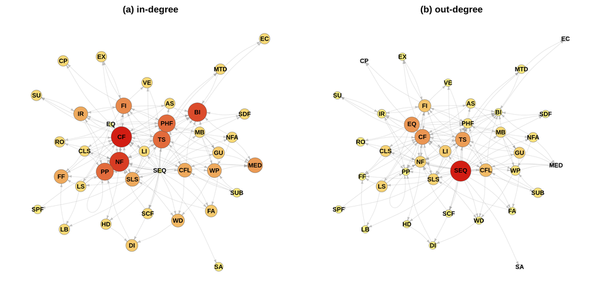

```r
pal <- colorRampPalette(c("#FFF886", "#d21d13"))
plot_deg <- function(g, layout, metric, zero_white = FALSE) {
  m <- metric / max(metric)
  col <- pal(500)[as.numeric(cut(m, breaks = 500))]; if (zero_white) col[metric == 0] <- "white"
  s <- sqrt(metric); vs <- 4 + (if (max(s)==0) 0 else s/max(s)) * 14
  plot(g, layout = layout, vertex.size = vs, vertex.color = col,
       vertex.frame.color = adjustcolor("grey30", .5),
       vertex.label = V(g)$name, vertex.label.family = "sans",
       vertex.label.color = "black", vertex.label.cex = .8, vertex.label.font = 2,
       edge.arrow.size = .35, edge.width = .6, edge.curved = .15,
       edge.color = adjustcolor("grey60", .45))
}
set.seed(123); lay1 <- layout_with_fr(g_marine, niter = 3000)
par(mfrow = c(1, 2), mar = c(0, 0, 2, 0))
plot_deg(g_marine, lay1, degree(g_marine, mode = "in"));  title("(a) in-degree")
plot_deg(g_marine, lay1, degree(g_marine, mode = "out"), zero_white = TRUE); title("(b) out-degree")
```

# 8 Figure 2

**What it shows / how it is made:** the marine (15 classes) and mainland (15 classes) networks on **one shared force-directed layout** so each class sits in the same place across panels. Four panels: marine in/out degree, mainland in/out degree; colour and size encode degree. This is the code behind `fig02a.png`.

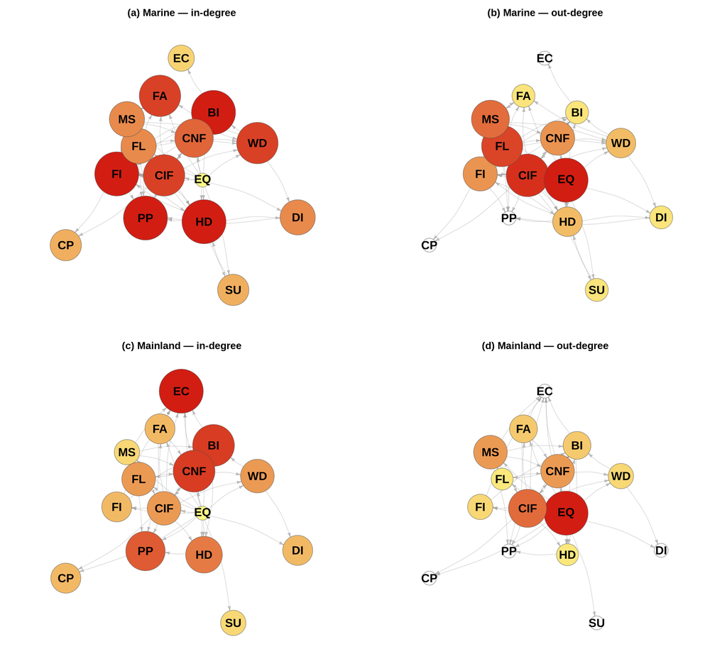

```r
abbr <- c("EQ or AS"="EQ","Mass Slide"="MS","Critical Infra. Fail."="CIF","Business Interr."="BI",
  "Water Dil."="WD","Critical NET Fail."="CNF","Flora an Fauna"="FA","Fire"="FI",
  "Healthcare Deg."="HD","Flood"="FL","Econ. Crisis"="EC","Disease"="DI",
  "Phy.-Psych. Trauma"="PP","Culture Perils"="CP","Social Unrest"="SU")
common <- sort(unique(c(V(g_marine_c)$name, V(g_mainland_c)$name)))
uni <- graph_from_data_frame(
  rbind(igraph::as_data_frame(g_marine_c), igraph::as_data_frame(g_mainland_c)),
  directed = TRUE, vertices = data.frame(name = common))
set.seed(123); lay2 <- layout_with_fr(uni, niter = 3000); rownames(lay2) <- V(uni)$name
panel <- function(g, mode, ttl) {
  m <- degree(g, mode = mode); mm <- if (max(m)==0) m else m/max(m)
  col <- pal(500)[as.numeric(cut(mm, breaks = 500))]; if (mode=="out") col[m==0] <- "white"
  s <- sqrt(m); vs <- 12 + (if (max(s)==0) 0 else s/max(s)) * 26
  plot(g, layout = lay2[V(g)$name, ], vertex.size = vs, vertex.color = col,
       vertex.frame.color = adjustcolor("grey30", .5), vertex.label = abbr[V(g)$name],vertex.label.family = "sans",
       vertex.label.color = "black", vertex.label.cex = 1.4, vertex.label.font = 2,
       edge.color = adjustcolor("grey60", .5), edge.width = .7, edge.arrow.size = .35,
       edge.curved = .15, main = ttl)
}
par(mfrow = c(2, 2), mar = c(1, 1, 2.5, 1))
panel(g_marine_c, "in", "(a) Marine — in-degree");    panel(g_marine_c, "out", "(b) Marine — out-degree")
panel(g_mainland_c, "in", "(c) Mainland — in-degree"); panel(g_mainland_c, "out", "(d) Mainland — out-degree")
```

# 9 Figure 3 / Sect. 3.4: robustness & sampling sufficiency

**What it shows / how it is made:** the 366 chains cluster under **58 source events (tsunamis)**, so all resampling is at the **event level** (cluster bootstrap). Panel (a) is the edge-accumulation (sampling-sufficiency) curve; panel (b) is the fraction of `B=1000` event-bootstrap resamples in which each qualitative conclusion holds (C1 pure sources; C2 dominant hubs SEQ/CF; C3 NF-as-convergence; C4 monotone four-layer cascade).

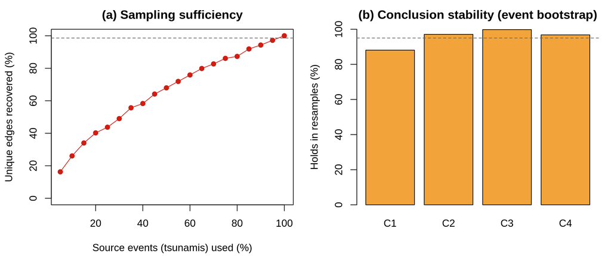

```r
set.seed(1)
x <- read_doc(marine_f)
id <- x[[ grep("^ID$|ID", names(x))[1] ]]; enc <- encoding_of(x)
cur <- NA; ev <- character(length(enc))                     # forward-fill event id
for (i in seq_along(enc)) { if (!is.na(id[i]) && nzchar(trimws(id[i]))) cur <- id[i]; ev[i] <- cur }
chain_edges <- lapply(seq_along(enc), function(i) {
  e <- character(0)
  for (seg in strsplit(enc[i], ";")[[1]]) { pr <- trimws(strsplit(seg, ",")[[1]])
    if (length(pr) >= 2 && all(nzchar(pr[1:2]))) e <- c(e, paste(pr[1], pr[2], sep = "|")) }
  unique(e) })
events   <- unique(ev)
ev_edges <- lapply(events, function(g) unique(unlist(chain_edges[ev == g])))
n_ev <- length(events); full <- length(unique(unlist(ev_edges)))
efreq <- table(unlist(ev_edges))

build_e  <- function(edges) { ee <- do.call(rbind, strsplit(edges, "\\|"))
  graph_from_data_frame(data.frame(from = ee[,1], to = ee[,2]), directed = TRUE) }
concl <- function(g) { dout <- degree(g, mode="out"); din <- degree(g, mode="in")
  nm <- V(g)$name; gv <- function(v,d) if (v%in%nm) d[v] else 0
  L <- layer_fine[nm]; nf <- sapply(L4, function(k) sum(dout[L==k]) - sum(din[L==k]))
  c(C1 = setequal(nm[din==0], c("SEQ","EQ")),
    C2 = (names(which.max(dout))=="SEQ" && names(which.max(din))=="CF"),
    C3 = (gv("NF",din) > gv("NF",dout)),
    C4 = (nf["Trigger"]>nf["Natural"] && nf["Natural"]>nf["Engineering"] &&
          nf["Engineering"]>nf["Consequence"] && nf["Trigger"]>0 && nf["Consequence"]<0)) }

B <- 1000
stab <- rowMeans(sapply(1:B, function(b)
  concl(build_e(unique(unlist(ev_edges[sample(n_ev, n_ev, replace = TRUE)])))))) * 100
fr  <- seq(.05, 1, .05)
acc <- sapply(fr, function(f) { k <- max(1, round(f*n_ev))
  mean(sapply(1:200, function(s) length(unique(unlist(ev_edges[sample(n_ev, k)]))))) })
fold <- sample(rep(1:5, length.out = n_ev))
core_cov <- mean(sapply(1:5, function(f) { tr <- unique(unlist(ev_edges[fold!=f]))
  te <- intersect(names(efreq)[efreq>=2], unique(unlist(ev_edges[fold==f])))
  if (length(te)==0) NA else 100*sum(te %in% tr)/length(te) }), na.rm = TRUE)

par(mfrow = c(1, 2), mar = c(4.2, 4.2, 2.4, 1))
plot(100*fr, 100*acc/full, type = "o", pch = 19, col = "#d21d13", ylim = c(0,100),
     xlab = "Source events (tsunamis) used (%)", ylab = "Unique edges recovered (%)",
     main = "(a) Sampling sufficiency")
abline(h = core_cov, lty = 2, col = "grey40")
barplot(stab, col = "#F2A43A", ylim = c(0,100), names.arg = c("C1","C2","C3","C4"),
        ylab = "Holds in resamples (%)", main = "(b) Conclusion stability (event bootstrap)")
abline(h = 95, lty = 2, col = "grey40")
```

```r
cat(sprintf("events=%d | C1..C4 hold in %s%% | core edges recovered out-of-sample: %.1f%%\n",
            n_ev, paste(round(stab), collapse="/"), core_cov))
```

```
## events=58 | C1..C4 hold in 88/97/100/97% | core edges recovered out-of-sample: 98.6%
```

# 10 Interactive viewer data

**What it makes / why:** the interactive network viewer linked from the figure captions (`docs/index.html`, served at https://hazardchain.github.io/NHESS-marine-seismic-hazard-chains-code-data/) is driven by `docs/graph-data.js`. This chunk regenerates that file **from the very same graph objects** used for the tables and figures above (`g_marine`, `g_marine_c`, `g_mainland_c`), so the web page, the paper figures, and the tables are guaranteed to be one and the same network — no hand-maintained copy can drift. `jsonlite` ships with `rmarkdown`, so knitting this document already provides it. The only extra input is the human-readable peril names used for the tooltips.

```r
## full peril names for the 39 fine nodes (viewer tooltips only; no metric uses them)
full_name_fine <- c(
  SEQ="Submarine Earthquake", EQ="Coastal Earthquake", AS="Aftershock", VE="Volcanic Eruption",
  SLS="Submarine Landslide", CLS="Coastal Landslide", LS="Landslide", RO="Rockfall", LB="Lake Burst",
  SA="Snow Avalanche", LI="Liquefaction", GU="Ground Uplift", SUB="Subsidence", MB="Methane Blowout",
  TS="Tsunami", CFL="Coastal Flooding", FF="Fluvial Flood", MED="Marine Ecosystem Damage",
  WP="Water Pollution", WD="Water Dilemma", DI="Disease", FA="Flora and Fauna",
  PHF="Port / Harbour Failure", SDF="Seawall / Dike Failure", SPF="Subsea Pipeline Failure",
  SCF="Subsea Cable Failure", NFA="Nuclear Facility Accident", FI="Fire", EX="Explosion",
  CF="Critical Infrastructure Failure", NF="Critical Network Failure",
  MTD="Maritime Transport Disruption", BI="Business Interruption", EC="Economic Crisis",
  PP="Physical & Psychological Trauma", HD="Healthcare Degradation", IR="Insufficient Rescue",
  SU="Social Unrest", CP="Culture Perils")
stopifnot(setequal(names(full_name_fine), V(g_marine)$name))  # every fine node has a name

ident <- function(g) { n <- V(g)$name; setNames(n, n) }
mk_nodes <- function(g, label, full, layer) {
  nm <- V(g)$name
  df <- data.frame(id = nm, label = unname(label[nm]), full = unname(full[nm]),
                   layer = unname(layer[nm]),
                   `in`  = as.integer(degree(g, mode = "in")),
                   out   = as.integer(degree(g, mode = "out")),
                   check.names = FALSE, stringsAsFactors = FALSE)
  df[order(df$id), , drop = FALSE]                 # deterministic order (platform-independent)
}
mk_edges <- function(g) { e <- igraph::as_data_frame(g)[, c("from", "to")]
  e[order(e$from, e$to), , drop = FALSE] }

GRAPHS <- list(
  fig1       = list(nodes = mk_nodes(g_marine,     ident(g_marine),     full_name_fine,     layer_fine),
                    edges = mk_edges(g_marine)),
  marine15   = list(nodes = mk_nodes(g_marine_c,   abbr, ident(g_marine_c),   layer15),
                    edges = mk_edges(g_marine_c)),
  mainland15 = list(nodes = mk_nodes(g_mainland_c, abbr, ident(g_mainland_c), layer15),
                    edges = mk_edges(g_mainland_c)))

if (!requireNamespace("jsonlite", quietly = TRUE)) {
  message("jsonlite not available; skipping docs/graph-data.js regeneration.")
} else if (dir.exists("docs")) {
  js <- paste0(
    "// Auto-generated by reproduce.Rmd from the docx sources in data/. Do not edit by hand.\n",
    "const GRAPHS = ", jsonlite::toJSON(GRAPHS, auto_unbox = TRUE, pretty = TRUE), ";\n")
  writeLines(js, file.path("docs", "graph-data.js"))
  cat(sprintf("Wrote docs/graph-data.js  |  fig1 %d/%d, marine15 %d/%d, mainland15 %d/%d (nodes/edges)\n",
    nrow(GRAPHS$fig1$nodes),       nrow(GRAPHS$fig1$edges),
    nrow(GRAPHS$marine15$nodes),   nrow(GRAPHS$marine15$edges),
    nrow(GRAPHS$mainland15$nodes), nrow(GRAPHS$mainland15$edges)))
} else {
  message("docs/ folder not found next to reproduce.Rmd; skipping viewer regeneration.")
}
```

```
## Wrote docs/graph-data.js  |  fig1 39/152, marine15 15/57, mainland15 15/47 (nodes/edges)
```

The web viewer therefore shares its single source of truth with Figs 1–2 and Tables 2–4: re-knit this document and the interactive page updates automatically.

# 11 Session information

```r
cat("OS:", Sys.info()[["sysname"]], Sys.info()[["release"]], "\n")
```

```
## OS: Linux 6.17.4-76061704-generic
```

[session information not shown]